# Praktikum 6 Anreg

Muhammad Daffa Fadhilah Athif

2026-06-26

# 1 Library

```r
library(GGally)    # untuk menghasilkan matriks hubungan antarpeubah
library(corrplot)  # untuk menghasilkan matriks korelasi
library(dplyr)     # untuk manipulasi data
library(car)        # untuk memeriksa multikolinearitas
library(stargazer) # untuk menampilkan hasil perbandingan regresi
library(lmtest)    # untuk uji kehomogenan ragam sisaan dan saling bebas
library(olsrr)     # untuk pemeriksaan amatan tidak biasa
```

# 2 Data

```r
dt <- read.csv2("C:\\Users\\ASUS\\OneDrive\\문서\\DAFFA\\IPB\\STK\\ANREG\\DATA RUMAH JABODETABEK ANREG.csv")
head(dt) # menampilkan sekian data awal
```

|  | price_in_rp | bedrooms | bathrooms | land_size_m2 | building_size_m2 | building_age |
| --- | --- | --- | --- | --- | --- | --- |
| 1 | 7.00e+10 | 5 | 5 | 680 | 1200 | 9 |
| 2 | 6.90e+10 | 4 | 4 | 475 | 1200 | 1 |
| 3 | 6.90e+10 | 4 | 5 | 474 | 1200 | 1 |
| 4 | 5.50e+10 | 12 | 12 | 2050 | 1500 | 12 |
| 5 | 4.51e+10 | 12 | 12 | 3475 | 1440 | 14 |
| 6 | 4.51e+10 | 12 | 12 | 3475 | 1440 | 14 |

```r
str(dt) # menampilkan tipe data setiap peubah
```

```
## 'data.frame':    1378 obs. of  6 variables:
##  $ price_in_rp     : num  7.00e+10 6.90e+10 6.90e+10 5.50e+10 4.51e+10 ...
##  $ bedrooms        : int  5 4 4 12 12 12 5 4 4 6 ...
##  $ bathrooms       : int  5 4 5 12 12 12 4 3 2 6 ...
##  $ land_size_m2    : int  680 475 474 2050 3475 3475 519 552 1592 640 ...
##  $ building_size_m2: int  1200 1200 1200 1500 1440 1440 470 900 938 1300 ...
##  $ building_age    : int  9 1 1 12 14 14 27 7 7 8 ...
```

```r
summary(dt) # menampilkan ringkasan data
```

```
##   price_in_rp           bedrooms        bathrooms       land_size_m2
##  Min.   :7.500e+07   Min.   : 1.000   Min.   : 1.000   Min.   :  12.0
##  1st Qu.:7.250e+08   1st Qu.: 2.000   1st Qu.: 2.000   1st Qu.:  72.0
##  Median :1.420e+09   Median : 3.000   Median : 2.000   Median : 100.0
##  Mean   :3.467e+09   Mean   : 3.172   Mean   : 2.483   Mean   : 171.8
##  3rd Qu.:3.650e+09   3rd Qu.: 4.000   3rd Qu.: 3.000   3rd Qu.: 180.0
##  Max.   :7.000e+10   Max.   :12.000   Max.   :13.000   Max.   :4445.0
##
##  building_size_m2  building_age
##  Min.   :  24.0   Min.   : 0.000
##  1st Qu.:  60.0   1st Qu.: 0.000
##  Median : 105.0   Median : 1.000
##  Mean   : 167.4   Mean   : 4.005
##  3rd Qu.: 200.0   3rd Qu.: 6.000
##  Max.   :1500.0   Max.   :49.000
##                   NA's   :54
```

Data yang digunakan adalah data harga rumah di kawasan Jabodetabek (Jakarta, Bogor, Depok, Tangerang, Bekasi) dengan 1 peubah respon yaitu harga rumah (`price_in_rp`) dan 5 peubah penjelas, yaitu jumlah kamar tidur (`bedrooms`), jumlah kamar mandi (`bathrooms`), luas tanah dalam m² (`land_size_m2`), luas bangunan dalam m² (`building_size_m2`), dan usia bangunan dalam tahun (`building_age`).

Karena harga rumah memiliki rentang nilai yang sangat besar dan menjulur ke kanan, maka peubah respon yang digunakan dalam pemodelan adalah `log_price`, yaitu logaritma natural dari `price_in_rp`. Selain itu, peubah `building_age` memiliki beberapa data kosong (NA) sehingga baris dengan data kosong tersebut dibuang sebelum pemodelan.

```r
dt[] <- lapply(dt, as.numeric)
dt <- na.omit(dt)
dt$log_price <- log(dt$price_in_rp)

# Hanya menggunakan peubah yang relevan untuk pemodelan
dt <- dt %>% select(log_price, bedrooms, bathrooms, land_size_m2, building_size_m2, building_age)
rownames(dt) <- 1:nrow(dt)
dim(dt)
```

```
## [1] 1324    6
```

Setelah pembersihan data, tersisa 1324 amatan yang akan digunakan pada keseluruhan pemodelan di praktikum ini.

# 3 Eksplorasi Data

## 3.1 Peubah Respon

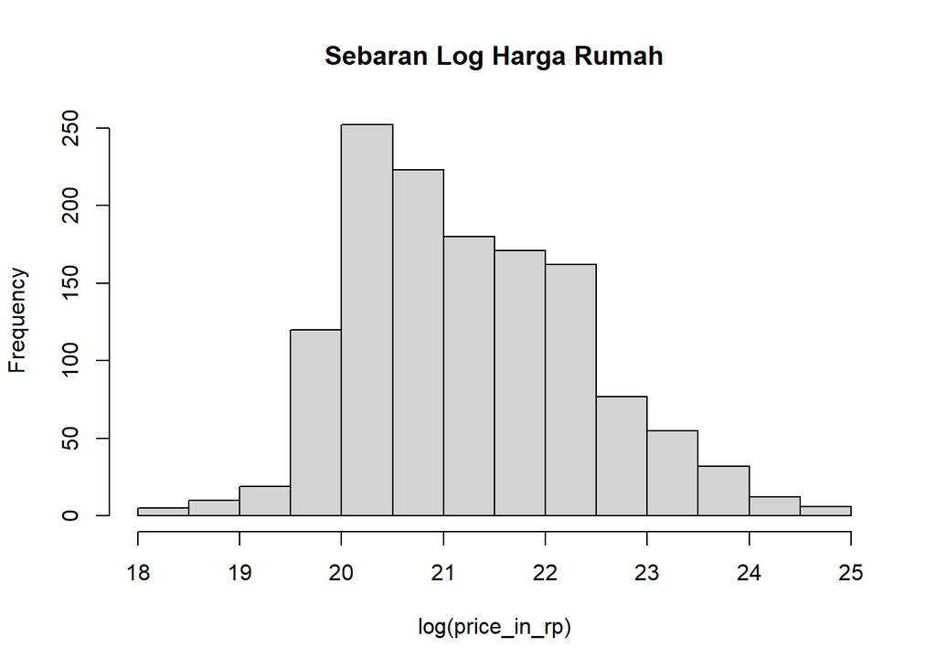

```r
hist(dt$log_price, main = "Sebaran Log Harga Rumah", xlab = "log(price_in_rp)")
```

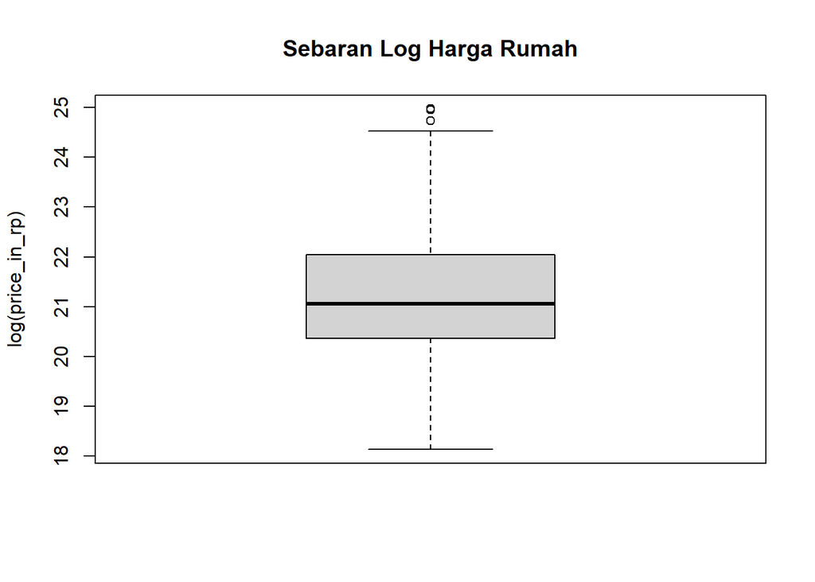

```r
boxplot(dt$log_price, main = "Sebaran Log Harga Rumah", ylab = "log(price_in_rp)")
```

## 3.2 Peubah Penjelas vs Peubah Respon

### 3.2.1 Bedrooms

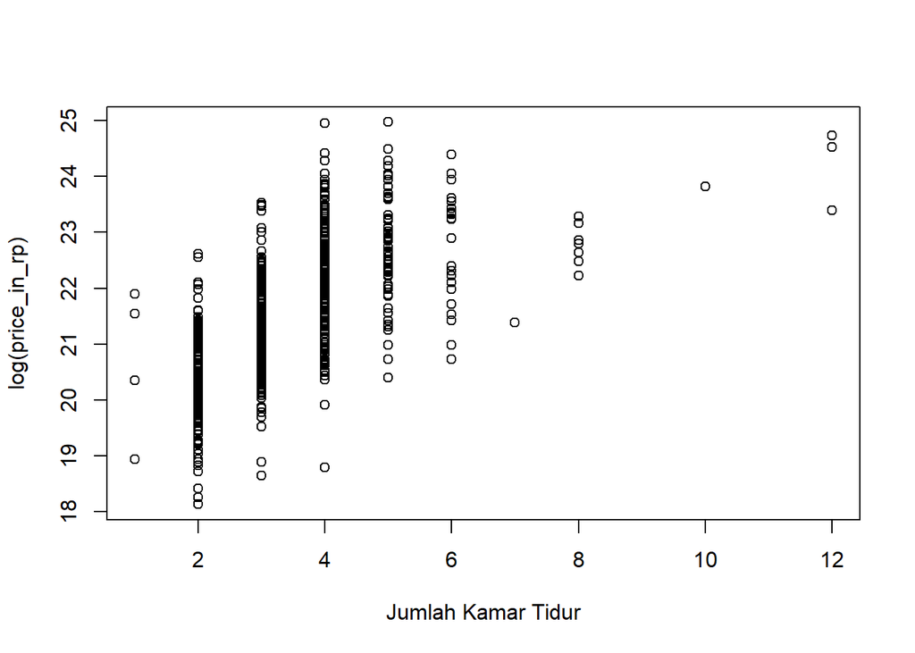

```r
plot(dt$bedrooms, dt$log_price, xlab = "Jumlah Kamar Tidur", ylab = "log(price_in_rp)")
```

Hubungan antara `bedrooms` dan `log_price` cenderung positif namun dengan sebaran yang cukup lebar pada setiap nilai `bedrooms`, mengindikasikan peubah ini saja belum cukup menjelaskan variasi harga rumah.

### 3.2.2 Bathrooms

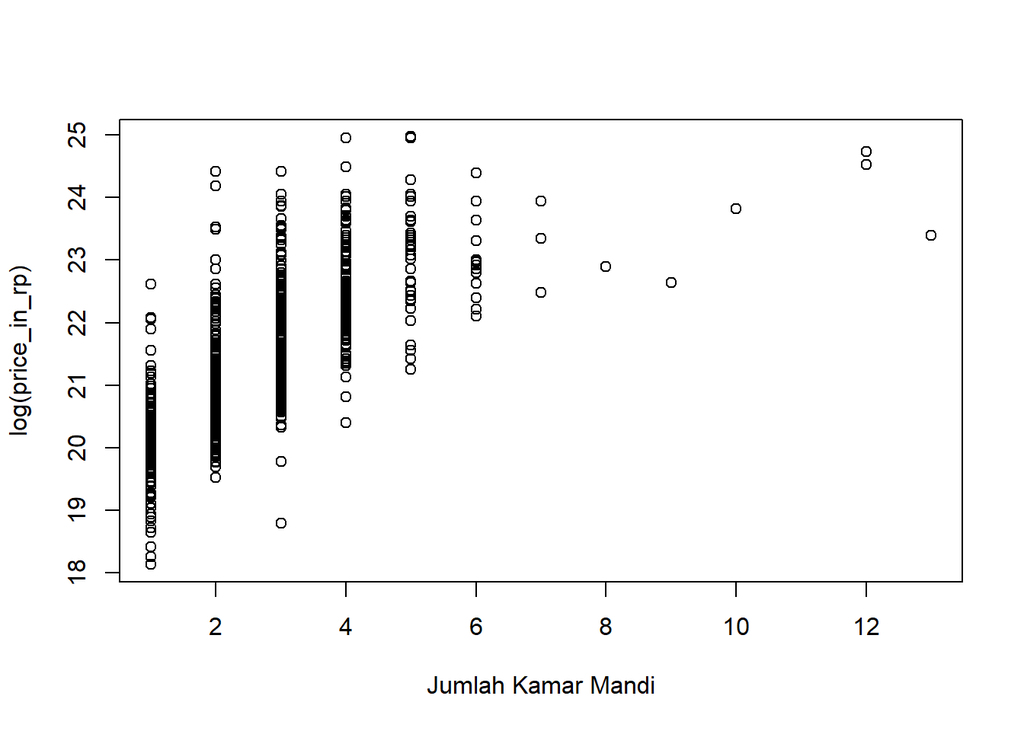

```r
plot(dt$bathrooms, dt$log_price, xlab = "Jumlah Kamar Mandi", ylab = "log(price_in_rp)")
```

Hubungan linearitas tampak cukup jelas antara `bathrooms` dan `log_price`, dengan kecenderungan harga rumah meningkat seiring bertambahnya jumlah kamar mandi.

### 3.2.3 Land Size

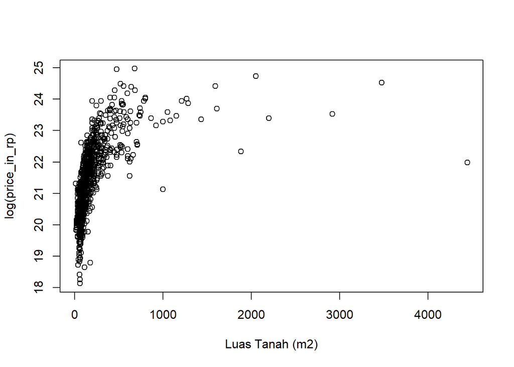

```r
plot(dt$land_size_m2, dt$log_price, xlab = "Luas Tanah (m2)", ylab = "log(price_in_rp)")
```

Terdapat beberapa amatan dengan luas tanah yang jauh lebih besar dibandingkan amatan lainnya, sehingga sebaran cenderung padat di sisi kiri dan jarang di sisi kanan.

### 3.2.4 Building Size

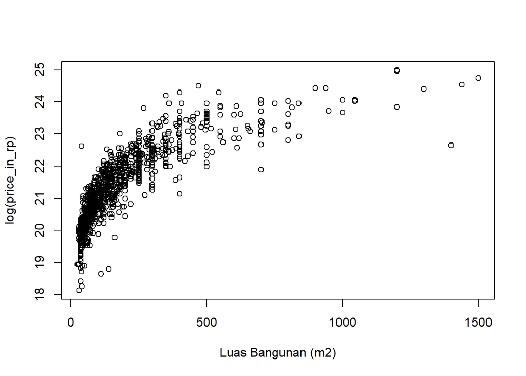

```r
plot(dt$building_size_m2, dt$log_price, xlab = "Luas Bangunan (m2)", ylab = "log(price_in_rp)")
```

Hubungan linearitas tampak paling jelas antara `building_size_m2` dan `log_price` dibandingkan peubah lainnya, sejalan dengan nilai korelasinya yang tertinggi terhadap peubah respon.

### 3.2.5 Building Age

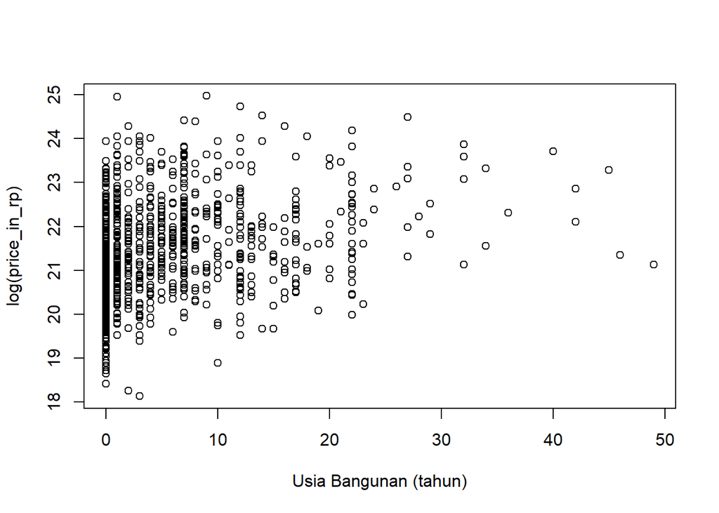

```r
plot(dt$building_age, dt$log_price, xlab = "Usia Bangunan (tahun)", ylab = "log(price_in_rp)")
```

Hubungan antara `building_age` dan `log_price` cenderung lemah dan sebarannya lebih acak dibandingkan peubah lainnya.

## 3.3 Korelasi

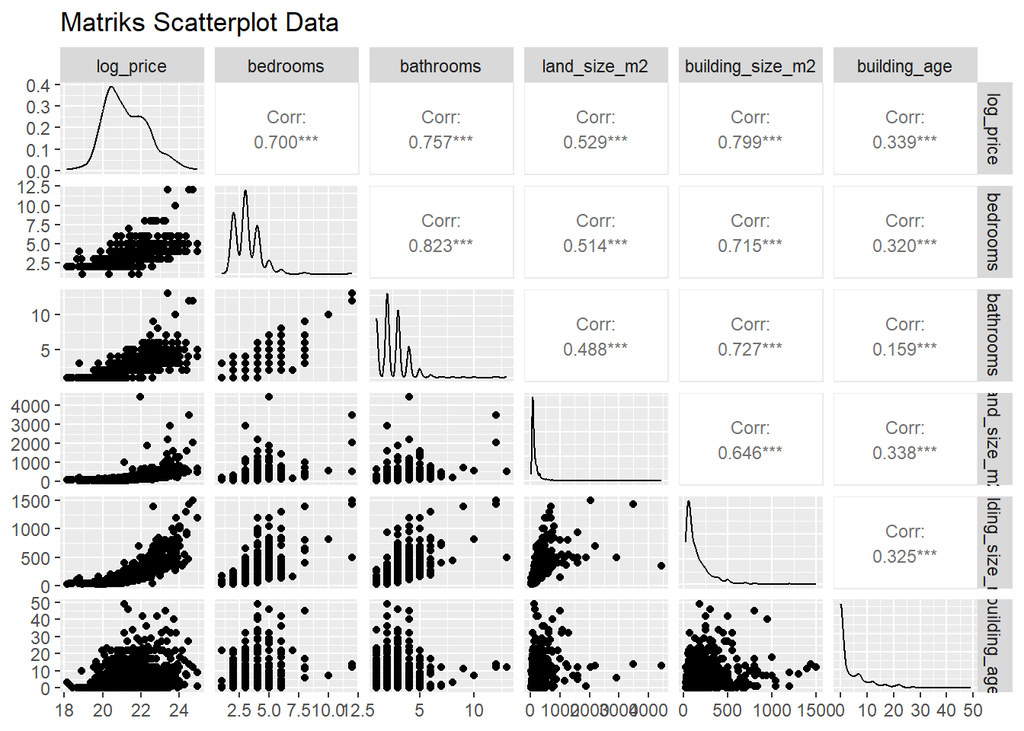

```r
ggpairs(dt,
        upper = list(continuous = wrap('cor', size = 3)),
        title = "Matriks Scatterplot Data")
```

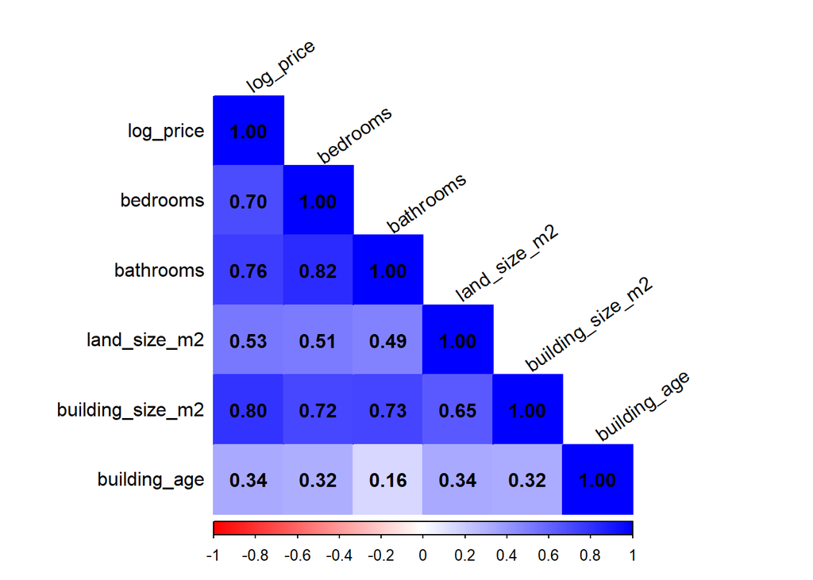

```r
cor_matrix <- cor(dt, use = "complete.obs")

corrplot(cor_matrix, method = "color", type = "lower",
         col = colorRampPalette(c("red", "white", "blue"))(200),
         addCoef.col = "black", tl.col = "black", tl.srt = 35)
```

Hasil matriks scatterplot dan korelasi menunjukkan bahwa peubah respon `log_price` memiliki hubungan positif dengan seluruh peubah penjelas. Korelasi tertinggi ditunjukkan oleh `building_size_m2` (0.80), diikuti `bathrooms` (0.76) dan `bedrooms` (0.70), sedangkan `land_size_m2` dan `building_age` memiliki korelasi yang lebih rendah (masing-masing sekitar 0.53 dan 0.34).

Selain itu, terdapat korelasi yang cukup tinggi antar beberapa peubah penjelas, di antaranya:  
1. `bedrooms` dan `bathrooms` memiliki korelasi 0.82.  
2. `building_size_m2` dengan `bedrooms` dan `bathrooms` masing-masing sebesar 0.72 dan 0.73.  
3. `land_size_m2` dengan `building_size_m2` memiliki korelasi 0.65.

Korelasi yang cukup tinggi antara `bedrooms` dan `bathrooms` mengindikasikan adanya potensi multikolinearitas, yang akan diperiksa lebih lanjut pada bagian berikutnya.

# 4 Pemodelan

```r
model1 <- lm(formula = log_price ~ ., data = dt)
summary(model1)
```

```
##
## Call:
## lm(formula = log_price ~ ., data = dt)
##
## Residuals:
##     Min      1Q  Median      3Q     Max
## -4.6812 -0.3216 -0.0138  0.3706  2.3482
##
## Coefficients:
##                    Estimate Std. Error t value Pr(>|t|)
## (Intercept)       1.982e+01  5.450e-02 363.640  < 2e-16 ***
## bedrooms         -3.615e-03  2.744e-02  -0.132    0.895
## bathrooms         3.444e-01  2.474e-02  13.921  < 2e-16 ***
## land_size_m2     -7.837e-05  8.215e-05  -0.954    0.340
## building_size_m2  3.037e-03  1.583e-04  19.185  < 2e-16 ***
## building_age      2.139e-02  2.781e-03   7.690 2.87e-14 ***
## ---
## Signif. codes:  0 '***' 0.001 '**' 0.01 '*' 0.05 '.' 0.1 ' ' 1
##
## Residual standard error: 0.6059 on 1318 degrees of freedom
## Multiple R-squared:  0.7179, Adjusted R-squared:  0.7168
## F-statistic: 670.7 on 5 and 1318 DF,  p-value: < 2.2e-16
```

Persamaan yang terbentuk adalah

$$\widehat{\text{log\_price}} = 19.82 -
0.0036\,\text{bedrooms} + 0.3444\,\text{bathrooms} -
0.00008\,\text{land\_size\_m2} + 0.0030\,\text{building\_size\_m2} +
0.0214\,\text{building\_age}$$

# 5 Pemeriksaan Multikolinearitas

## 5.1 Perubahan Peubah

```r
mod1 <- lm(log_price ~ ., dt[, 1:2])
mod2 <- lm(log_price ~ ., dt[, 1:3])
mod3 <- lm(log_price ~ ., dt[, 1:4])
mod4 <- lm(log_price ~ ., dt[, 1:5])
mod5 <- lm(log_price ~ ., dt)

stargazer(mod1, mod2, mod3, mod4, mod5,
          type = "text", single.row = TRUE)
```

```
##
## =======================================================================================================================================================
##                                                                             Dependent variable:
##                     -----------------------------------------------------------------------------------------------------------------------------------
##                                                                                  log_price
##                                 (1)                        (2)                       (3)                       (4)                       (5)
## -------------------------------------------------------------------------------------------------------------------------------------------------------
## bedrooms                 0.685*** (0.019)           0.234*** (0.030)          0.171*** (0.030)           0.051* (0.027)            -0.004 (0.027)
## bathrooms                                           0.487*** (0.027)          0.455*** (0.026)          0.295*** (0.024)          0.344*** (0.025)
## land_size_m2                                                                  0.001*** (0.0001)         0.00003 (0.0001)          -0.0001 (0.0001)
## building_size_m2                                                                                        0.003*** (0.0002)         0.003*** (0.0002)
## building_age                                                                                                                      0.021*** (0.003)
## Constant                 19.067*** (0.065)          19.295*** (0.060)         19.440*** (0.060)         19.808*** (0.056)         19.818*** (0.054)
## -------------------------------------------------------------------------------------------------------------------------------------------------------
## Observations                   1,324                      1,324                     1,324                     1,324                     1,324
## R2                             0.490                      0.591                     0.616                     0.705                     0.718
## Adjusted R2                    0.490                      0.591                     0.615                     0.704                     0.717
## Residual Std. Error      0.813 (df = 1322)          0.728 (df = 1321)         0.707 (df = 1320)         0.619 (df = 1319)         0.606 (df = 1318)
## F Statistic         1,269.616*** (df = 1; 1322) 955.981*** (df = 2; 1321) 704.926*** (df = 3; 1320) 788.808*** (df = 4; 1319) 670.683*** (df = 5; 1318)
## =======================================================================================================================================================
## Note:                                                                                                                       *p<0.1; **p<0.05; ***p<0.01
```

Penambahan peubah satu demi satu menunjukkan bahwa koefisien `bedrooms` berubah cukup besar, bahkan berubah tanda dari positif (saat sendirian di `mod1`) menjadi negatif setelah peubah lain ditambahkan. Hal ini mengindikasikan adanya hubungan yang tumpang tindih antara `bedrooms` dengan peubah penjelas lainnya, khususnya `bathrooms`, sehingga perlu dicermati lebih lanjut melalui nilai VIF.

## 5.2 Perubahan Banyak Data

```r
set.seed(123)
dt_sampel <- dt[sample(1:nrow(dt), 200), ]
mod5_sampel <- lm(log_price ~ ., dt_sampel)
stargazer(summary(mod5)$coefficients, summary(mod5_sampel)$coefficients,
          type = "text",
          font.size = "small")
```

```
##
## ========================================================
##                  Estimate Std. Error t value Pr(> | t| )
## --------------------------------------------------------
## (Intercept)       19.818    0.054    363.640      0
## bedrooms          -0.004    0.027    -0.132     0.895
## bathrooms         0.344     0.025    13.921       0
## land_size_m2     -0.0001    0.0001   -0.954     0.340
## building_size_m2  0.003     0.0002   19.185       0
## building_age      0.021     0.003     7.690       0
## --------------------------------------------------------
##
## ========================================================
##                  Estimate Std. Error t value Pr(> | t| )
## --------------------------------------------------------
## (Intercept)       19.291    0.128    151.182      0
## bedrooms          0.207     0.058     3.547    0.0005
## bathrooms         0.249     0.055     4.501    0.00001
## land_size_m2      0.001     0.0003    2.121     0.035
## building_size_m2  0.003     0.0005    6.210       0
## building_age      0.008     0.007     1.044     0.298
## --------------------------------------------------------
```

## 5.3 Akar Ciri

```r
x <- dt[-1]
r <- cor(x)
(ev <- eigen(r)$values)
```

```
## [1] 3.1212470 0.9112907 0.5528811 0.2578061 0.1567751
```

```r
# Simultan
if ((max(ev) / min(ev)) <= 100) {
  cat("Tidak ada multikolinearitas\n")
} else if ((max(ev) / min(ev)) > 100 & (max(ev) / min(ev)) <= 1000) {
  cat("Ada multikolinearitas yang lemah\n")
} else {
  cat("Ada multikolinearitas yang kuat\n")
}
```

```
## Tidak ada multikolinearitas
```

```r
# Parsial
if (all((max(ev) / ev) <= 1000)) {
  cat("Tidak ada multikolinearitas\n")
} else {
  cat("Ada multikolinearitas pada peubah penjelas ke:", which((max(ev) / ev) > 1000), "\n")
}
```

```
## Tidak ada multikolinearitas
```

## 5.4 Nilai VIF

```r
vif(model1)
```

```
##         bedrooms        bathrooms     land_size_m2 building_size_m2
##         3.674332         3.788821         1.782886         2.982043
##     building_age
##         1.255800
```

Hasil pemeriksaan dengan akar ciri menyatakan tidak ada multikolinearitas pada model karena rasio akar ciri terbesar terhadap terkecil tidak melebihi 100. Nilai VIF juga menunjukkan tidak ada peubah dengan VIF lebih dari 10, bahkan seluruhnya berada di bawah 5. Dengan demikian, secara keseluruhan tidak ditemukan indikasi multikolinearitas yang serius pada model ini. Meski demikian, karena peubah `bedrooms` dan `land_size_m2` tidak signifikan secara individu, penanganan tetap dilakukan dengan mengeluarkan kedua peubah tersebut dari model agar model menjadi lebih sederhana (parsimoni) tanpa kehilangan informasi penting.

# 6 Pemodelan Penyisihan Peubah

```r
model2 <- lm(log_price ~ bathrooms + building_size_m2 + building_age, data = dt)
summary(model2)
```

```
##
## Call:
## lm(formula = log_price ~ bathrooms + building_size_m2 + building_age,
##     data = dt)
##
## Residuals:
##     Min      1Q  Median      3Q     Max
## -4.6309 -0.3197 -0.0155  0.3738  2.3445
##
## Coefficients:
##                   Estimate Std. Error t value Pr(>|t|)
## (Intercept)      1.981e+01  3.826e-02 517.939  < 2e-16 ***
## bathrooms        3.413e-01  1.865e-02  18.301  < 2e-16 ***
## building_size_m2 2.969e-03  1.404e-04  21.148  < 2e-16 ***
## building_age     2.082e-02  2.642e-03   7.881 6.74e-15 ***
## ---
## Signif. codes:  0 '***' 0.001 '**' 0.01 '*' 0.05 '.' 0.1 ' ' 1
##
## Residual standard error: 0.6057 on 1320 degrees of freedom
## Multiple R-squared:  0.7177, Adjusted R-squared:  0.717
## F-statistic:  1118 on 3 and 1320 DF,  p-value: < 2.2e-16
```

Persamaan yang terbentuk adalah

$$\widehat{\text{log\_price}} = 19.81 +
0.3413\,\text{bathrooms} + 0.0030\,\text{building\_size\_m2} +
0.0208\,\text{building\_age}$$

Pada ringkasan model ini dapat dilihat bahwa secara simultan model signifikan, dan kini seluruh peubah penjelas juga signifikan secara individu pada taraf nyata 5%. Tidak ada perubahan tanda koefisien yang berlawanan dengan arah korelasi pada model ini.

## 6.1 Nilai VIF

```r
vif(model2)
```

```
##        bathrooms building_size_m2     building_age
##         2.153853         2.346502         1.133696
```

Model hasil reduksi peubah menunjukkan bahwa nilai VIF seluruh peubah jauh di bawah 10, bahkan di bawah 3, sehingga dinyatakan tidak terjadi multikolinearitas. Walaupun model ini secara koefisien sudah baik, perlu dilakukan uji asumsi sisaan serta pemeriksaan pencilan, leverage, dan amatan berpengaruh untuk memastikan model benar-benar layak digunakan.

# 7 Pengujian Asumsi

## 7.1 Eksplorasi Grafik

### 7.1.1 Plot Sisaan vs Y Duga

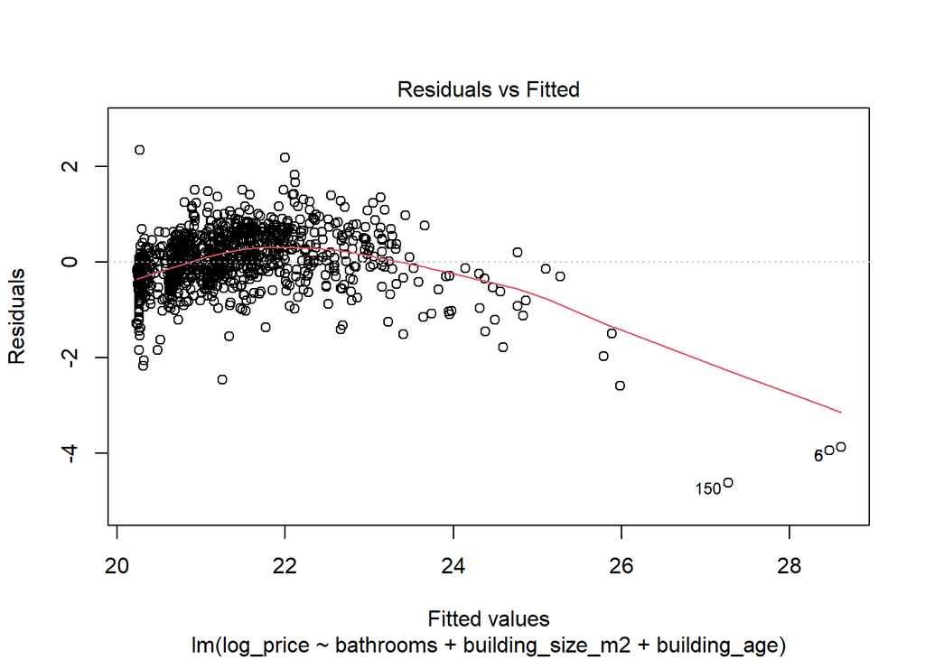

```r
plot(model2, 1)
```

### 7.1.2 Plot Sisaan vs Urutan

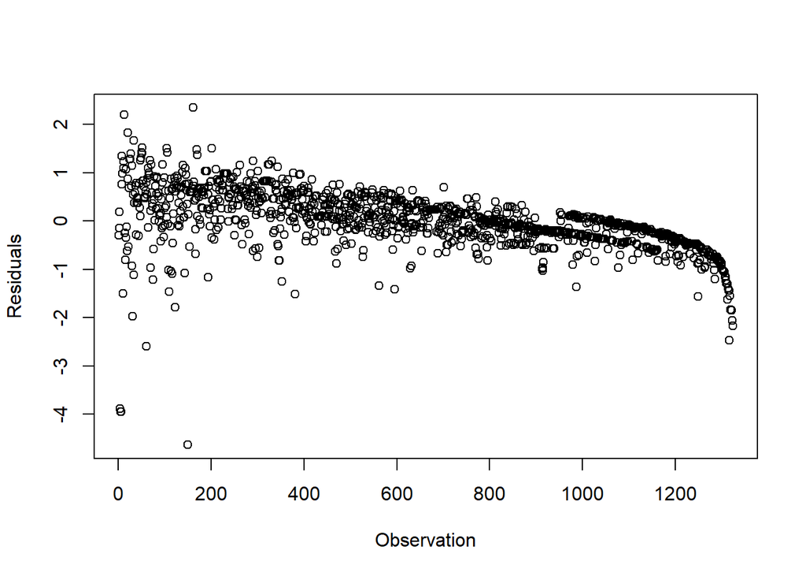

```r
plot(x = 1:dim(dt)[1],
     y = model2$residuals,
     type = 'p',
     ylab = "Residuals",
     xlab = "Observation")
```

### 7.1.3 QQ Plot

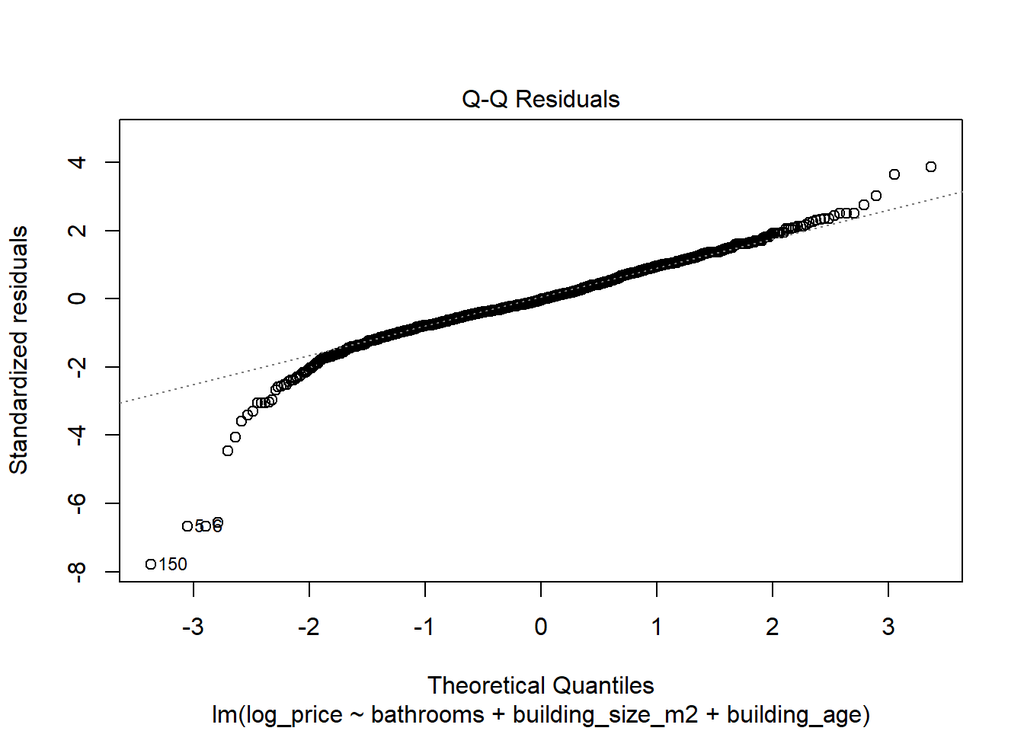

```r
plot(model2, 2)
```

Pada bagian ekor kiri dan ekor kanan, banyak titik amatan menjauh dari garis acuan, sehingga sisaan terindikasi tidak menyebar normal.

## 7.2 Uji Formal

### 7.2.1 Nilai Harapan Sisaan Sama dengan Nol

```r
t.test(model2$residuals, mu = 0, conf.level = 0.95)
```

```
##
##  One Sample t-test
##
## data:  model2$residuals
## t = 1.7592e-14, df = 1323, p-value = 1
## alternative hypothesis: true mean is not equal to 0
## 95 percent confidence interval:
##  -0.03261764  0.03261764
## sample estimates:
##    mean of x
## 2.924971e-16
```

Nilai p pada uji t sama dengan 1 yang lebih besar dari alpha 5%, sehingga dinyatakan asumsi nilai harapan sisaan sama dengan nol terpenuhi. Hasil ini secara teoritis selalu terpenuhi pada model regresi linear dengan metode kuadrat terkecil, karena sisaan akan selalu memiliki rata-rata nol.

### 7.2.2 Ragam Sisaan Homogen

```r
bptest(model2)
```

```
##
##  studentized Breusch-Pagan test
##
## data:  model2
## BP = 250.62, df = 3, p-value < 2.2e-16
```

### 7.2.3 Sisaan Saling Bebas

```r
dwtest(model2)
```

```
##
##  Durbin-Watson test
##
## data:  model2
## DW = 0.94183, p-value < 2.2e-16
## alternative hypothesis: true autocorrelation is greater than 0
```

Uji Durbin-Watson menunjukkan nilai p yang sangat kecil, namun perlu dicatat bahwa uji ini dirancang untuk mendeteksi autokorelasi pada data deret waktu berdasarkan urutan pengamatan. Karena data rumah Jabodetabek bersifat cross-sectional dan urutan barisnya tidak memiliki makna waktu, hasil uji Durbin-Watson di sini lebih mengindikasikan adanya pengelompokan/struktur tertentu pada urutan data (kemungkinan data dikumpulkan per wilayah atau per sumber) dibanding autokorelasi temporal yang sesungguhnya. Indikasi ini sebaiknya ditindaklanjuti dengan memeriksa struktur pengelompokan pada data asli, bukan diinterpretasikan sebagai pelanggaran asumsi independensi galat secara baku.

### 7.2.4 Normalitas Sisaan

```r
shapiro.test(model2$residuals)
```

```
##
##  Shapiro-Wilk normality test
##
## data:  model2$residuals
## W = 0.93821, p-value < 2.2e-16
```

Nilai p pada uji Shapiro-Wilk jauh lebih kecil dari alpha 5%, sehingga dinyatakan asumsi normalitas sisaan **tidak terpenuhi**.

Asumsi ragam sisaan homogen dan normalitas sisaan tidak terpenuhi pada model ini, kemungkinan disebabkan oleh keberadaan amatan yang tidak biasa seperti pencilan, leverage, atau amatan berpengaruh, mengingat data harga rumah umumnya memiliki sebagian kecil properti dengan karakteristik sangat berbeda (misalnya rumah mewah dengan harga jauh di atas rata-rata).

# 8 Pemeriksaan Amatan Tidak Biasa

```r
# fungsi
ri_stud <- rstudent(model2)
ri_stan <- rstandard(model2)
hii_fungsi <- hatvalues(model2)

# manual
X <- model.matrix(model2)
X_inv_xt <- X %*% solve(t(X) %*% X) %*% t(X)
hii_manual <- diag(X_inv_xt)
anova_model <- anova(model2)
s <- sqrt(anova_model["Residuals", "Mean Sq"])
ei <- model2$residuals
ri_manual <- ei / (s * sqrt(1 - hii_manual))

nilai <- data.frame(ri_stud, ri_stan, ri_manual, hii_fungsi, hii_manual)
head(nilai, 10)
```

|  | ri_stud | ri_stan | ri_manual | hii_fungsi | hii_manual |
| --- | --- | --- | --- | --- | --- |
| 1 | -0.5022967 | -0.5024390 | -0.5024390 | 0.034725662 | 0.034725662 |
| 2 | 0.3285122 | 0.3286232 | 0.3286232 | 0.045835473 | 0.045835473 |
| 3 | -0.2471840 | -0.2472720 | -0.2472720 | 0.038921465 | 0.038921465 |
| 4 | -6.6763027 | -6.5687659 | -6.5687659 | 0.047991113 | 0.047991113 |
| 5 | -6.7774352 | -6.6649451 | -6.6649451 | 0.045507435 | 0.045507435 |
| 6 | -6.7774352 | -6.6649451 | -6.6649451 | 0.045507435 | 0.045507435 |
| 7 | 2.2389763 | 2.2355806 | 2.2355806 | 0.009946398 | 0.009946398 |
| 8 | 1.2643365 | 1.2640499 | 1.2640499 | 0.024659330 | 0.024659330 |
| 9 | 1.6560632 | 1.6549712 | 1.6549712 | 0.035255757 | 0.035255757 |
| 10 | -2.5322743 | -2.5270987 | -2.5270987 | 0.038052613 | 0.038052613 |

Karena data berjumlah 1324 amatan, pemeriksaan amatan tidak biasa pada praktikum ini dirangkum secara agregat (jumlah dan proporsi amatan yang terdeteksi), bukan ditelusuri satu per satu seperti pada data berukuran kecil.

## 8.1 Pencilan

```r
absri <- abs(nilai$ri_stan)
pencilan <- which(absri > 2)
cat("Jumlah amatan terdeteksi sebagai pencilan:", length(pencilan), "dari", nrow(dt),
    "amatan (", round(length(pencilan) / nrow(dt) * 100, 2), "%)\n")
```

```
## Jumlah amatan terdeteksi sebagai pencilan: 55 dari 1324 amatan ( 4.15 %)
```

```r
head(pencilan, 20)
```

```
##  [1]  4  5  6  7 10 12 13 20 24 25 26 27 31 33 48 49 50 51 52 61
```

Sekitar 4.15% amatan terdeteksi sebagai pencilan berdasarkan kriteria $|r_i| > 2$. Proporsi ini relatif kecil namun tidak diabaikan, sejalan dengan dugaan bahwa terdapat sebagian rumah dengan karakteristik harga yang menyimpang dari pola umum.

## 8.2 Leverage

```r
n <- dim(dt)[1]
p <- length(model2$coefficients)
cutoff <- 2 * p / n

titik_leverage <- which(hii_fungsi > cutoff)
cat("Cutoff leverage (2p/n):", round(cutoff, 5), "\n")
```

```
## Cutoff leverage (2p/n): 0.00604
```

```r
cat("Jumlah titik leverage:", length(titik_leverage), "dari", n,
    "amatan (", round(length(titik_leverage) / n * 100, 2), "%)\n")
```

```
## Jumlah titik leverage: 118 dari 1324 amatan ( 8.91 %)
```

```r
head(titik_leverage, 20)
```

```
##  1  2  3  4  5  6  7  8  9 10 13 14 15 16 17 18 19 22 23 28
##  1  2  3  4  5  6  7  8  9 10 13 14 15 16 17 18 19 22 23 28
```

Sekitar 8.91% amatan terdeteksi sebagai titik leverage, yaitu amatan dengan kombinasi nilai peubah penjelas yang relatif ekstrem dibandingkan amatan lainnya.

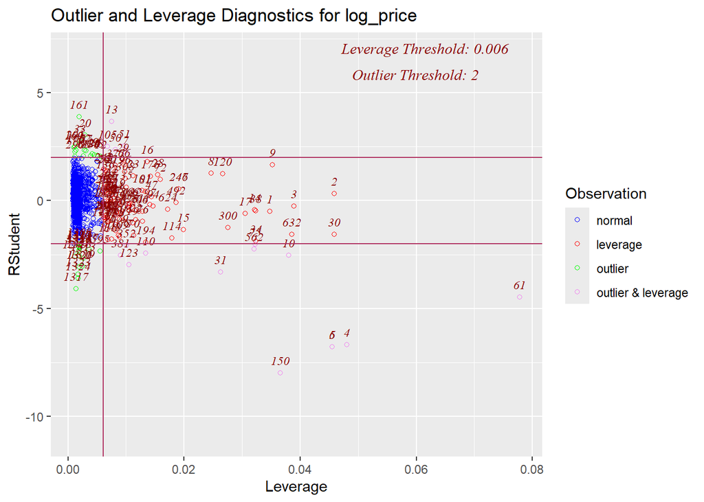

```r
ols_plot_resid_lev(model2)
```

Plot yang terbentuk dari fungsi `ols_plot_resid_lev()` menunjukkan sebaran amatan berdasarkan sisaan terstandardisasi dan leverage secara bersamaan, sehingga titik-titik yang berada di luar kedua ambang batas (baik secara vertikal maupun horizontal) dapat dengan cepat diidentifikasi sebagai pencilan, leverage, atau keduanya.

## 8.3 Amatan Berpengaruh

### 8.3.1 Jarak Cook

```r
di <- cooks.distance(model2)
f <- qf(0.05, p, n - p, lower.tail = FALSE)
cat("Cutoff Jarak Cook (berdasarkan distribusi F):", round(f, 4), "\n")
```

```
## Cutoff Jarak Cook (berdasarkan distribusi F): 2.3787
```

```r
cat("Jumlah amatan dengan Jarak Cook melebihi cutoff F:", sum(di > f), "\n")
```

```
## Jumlah amatan dengan Jarak Cook melebihi cutoff F: 0
```

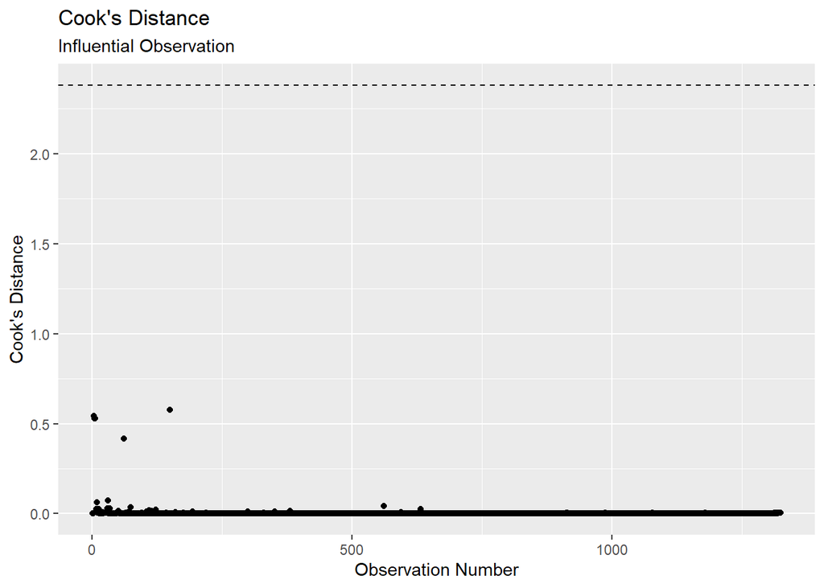

```r
cooks_crit <- f
model_cooks <- di
df <- data.frame(obs = as.numeric(names(model_cooks)),
                  cooks = model_cooks)
ggplot(df, aes(y = cooks, x = obs)) +
  geom_point() +
  geom_hline(yintercept = cooks_crit, linetype = "dashed") +
  labs(title = "Cook's Distance",
       subtitle = "Influential Observation",
       x = "Observation Number",
       y = "Cook's Distance")
```

Pemeriksaan amatan berpengaruh dengan jarak Cook menggunakan cutoff berdasarkan distribusi F tidak menghasilkan amatan yang melebihi ambang batas tersebut, karena cutoff ini cenderung sangat konservatif untuk ukuran data yang besar. Sebagai alternatif yang lebih umum digunakan pada data berukuran besar, dapat digunakan cutoff $4/n$.

```r
cutoff_cook_alt <- 4 / n
melebihi_cook_alt <- which(di > cutoff_cook_alt)
cat("Cutoff alternatif (4/n):", round(cutoff_cook_alt, 5), "\n")
```

```
## Cutoff alternatif (4/n): 0.00302
```

```r
cat("Jumlah amatan dengan Jarak Cook melebihi cutoff 4/n:", length(melebihi_cook_alt),
    "dari", n, "amatan (", round(length(melebihi_cook_alt) / n * 100, 2), "%)\n")
```

```
## Jumlah amatan dengan Jarak Cook melebihi cutoff 4/n: 76 dari 1324 amatan ( 5.74 %)
```

### 8.3.2 DFBETAS

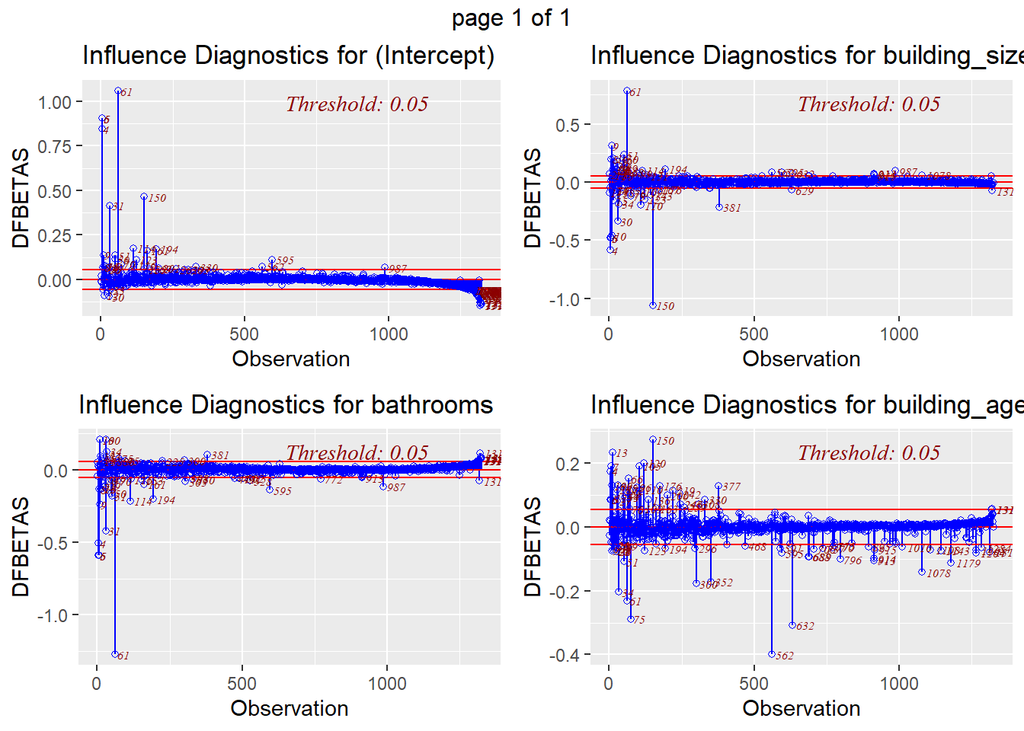

```r
ols_plot_dfbetas(model2)
```

Hasil DFBETAS menunjukkan pengaruh masing-masing observasi terhadap setiap koefisien regresi, sehingga terdapat satu plot untuk setiap parameter regresi. DFBETAS mengukur seberapa besar koefisien regresi berubah jika suatu observasi dihapus dari model. Pada plot ini, garis ambang batas membantu mengidentifikasi observasi-observasi yang pengaruhnya terhadap koefisien tertentu cukup besar.

### 8.3.3 DFFITS

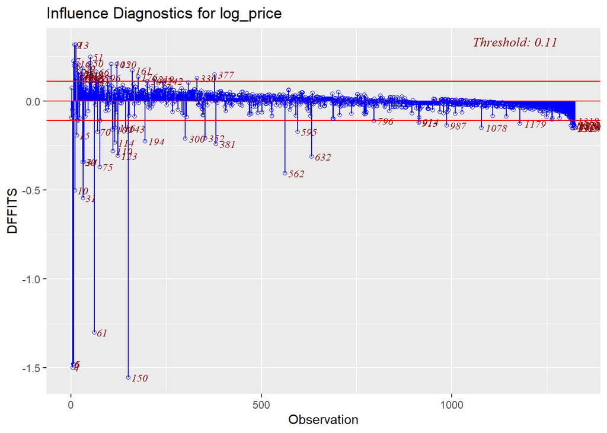

```r
ols_plot_dffits(model2)
```

Hasil DFFITS menunjukkan pengaruh observasi terhadap nilai prediksi Y, sehingga hanya menghasilkan satu output. DFFITS mengukur seberapa besar nilai prediksi $\hat{Y}_i$ berubah jika suatu observasi dihapus dari model, sehingga lebih tepat digunakan untuk melihat pengaruh observasi terhadap hasil model secara keseluruhan.

```r
DFFITSi <- dffits(model2)
cutoff_dffits <- 2 * sqrt(p / n)
amatan_berpengaruh <- which(abs(DFFITSi) > cutoff_dffits)

cat("Cutoff DFFITS:", round(cutoff_dffits, 4), "\n")
```

```
## Cutoff DFFITS: 0.1099
```

```r
cat("Jumlah amatan berpengaruh (DFFITS):", length(amatan_berpengaruh), "dari", n,
    "amatan (", round(length(amatan_berpengaruh) / n * 100, 2), "%)\n")
```

```
## Jumlah amatan berpengaruh (DFFITS): 76 dari 1324 amatan ( 5.74 %)
```

Berdasarkan kriteria DFFITS, terdapat sejumlah amatan yang teridentifikasi cukup berpengaruh terhadap nilai prediksi model. Karena jumlahnya cukup banyak dan tidak mungkin ditelusuri satu per satu seperti pada data berukuran kecil, pada bagian berikutnya akan dibandingkan performa model ketika seluruh amatan tidak biasa (gabungan pencilan, leverage, dan amatan berpengaruh) disisihkan secara bersamaan.

# 9 Pemodelan Penyisihan Amatan

```r
# Gabungan amatan tidak biasa: pencilan, leverage, dan amatan berpengaruh (DFFITS)
gabungan_tidak_biasa <- sort(unique(c(pencilan, titik_leverage, amatan_berpengaruh)))

cat("Jumlah total amatan tidak biasa (gabungan, tanpa duplikasi):", length(gabungan_tidak_biasa),
    "dari", n, "amatan (", round(length(gabungan_tidak_biasa) / n * 100, 2), "%)\n")
```

```
## Jumlah total amatan tidak biasa (gabungan, tanpa duplikasi): 159 dari 1324 amatan ( 12.01 %)
```

```r
# Model setelah menyisihkan amatan tidak biasa
dt_bersih <- dt[-gabungan_tidak_biasa, ]
model3 <- lm(log_price ~ bathrooms + building_size_m2 + building_age, data = dt_bersih)
summary(model3)
```

```
##
## Call:
## lm(formula = log_price ~ bathrooms + building_size_m2 + building_age,
##     data = dt_bersih)
##
## Residuals:
##     Min      1Q  Median      3Q     Max
## -1.5127 -0.2529 -0.0212  0.2722  1.1420
##
## Coefficients:
##                   Estimate Std. Error t value Pr(>|t|)
## (Intercept)      1.953e+01  3.189e-02 612.325  < 2e-16 ***
## bathrooms        3.936e-01  1.841e-02  21.374  < 2e-16 ***
## building_size_m2 4.551e-03  1.885e-04  24.143  < 2e-16 ***
## building_age     1.583e-02  3.006e-03   5.268 1.64e-07 ***
## ---
## Signif. codes:  0 '***' 0.001 '**' 0.01 '*' 0.05 '.' 0.1 ' ' 1
##
## Residual standard error: 0.4121 on 1161 degrees of freedom
## Multiple R-squared:  0.812,  Adjusted R-squared:  0.8115
## F-statistic:  1671 on 3 and 1161 DF,  p-value: < 2.2e-16
```

```r
get_metrics <- function(model) {
  adj_r2 <- summary(model)$adj.r.squared
  sse <- sum(model$residuals^2)
  return(c(adj_r2, sse))
}

model_metrics <- data.frame(
  Model = c("Model Awal (Model 2)", "Model Penyisihan Amatan (Model 3)"),
  Adjusted_R2 = sapply(list(model2, model3), function(m) get_metrics(m)[1]),
  SSE = sapply(list(model2, model3), function(m) get_metrics(m)[2])
)

print(model_metrics)
```

```
##                               Model Adjusted_R2      SSE
## 1              Model Awal (Model 2)    0.717015 484.2412
## 2 Model Penyisihan Amatan (Model 3)    0.811491 197.2135
```

Berdasarkan hasil perbandingan tersebut, model yang menyisihkan seluruh amatan tidak biasa (Model 3) memiliki nilai Adjusted R-squared yang jauh lebih besar dan SSE yang jauh lebih kecil dibandingkan model awal (Model 2). Hal ini menunjukkan bahwa keberadaan amatan-amatan tidak biasa tersebut, meskipun secara proporsi relatif kecil terhadap keseluruhan data, memberikan kontribusi besar terhadap keragaman sisaan yang tidak dapat dijelaskan oleh model.

```r
stargazer(model2, model3, type = "text", font.size = "small",
          report = "vc*p")
```

```
##
## ===========================================================================
##                                       Dependent variable:
##                     -------------------------------------------------------
##                                            log_price
##                                 (1)                         (2)
## ---------------------------------------------------------------------------
## bathrooms                    0.341***                    0.394***
##                              p = 0.000                   p = 0.000
##
## building_size_m2             0.003***                    0.005***
##                              p = 0.000                   p = 0.000
##
## building_age                 0.021***                    0.016***
##                              p = 0.000                  p = 0.00000
##
## Constant                     19.815***                   19.527***
##                              p = 0.000                   p = 0.000
##
## ---------------------------------------------------------------------------
## Observations                   1,324                       1,165
## R2                             0.718                       0.812
## Adjusted R2                    0.717                       0.811
## Residual Std. Error      0.606 (df = 1320)           0.412 (df = 1161)
## F Statistic         1,118.387*** (df = 3; 1320) 1,671.257*** (df = 3; 1161)
## ===========================================================================
## Note:                                           *p<0.1; **p<0.05; ***p<0.01
```

```r
cat("--- Cek ulang asumsi pada model setelah penyisihan amatan ---\n")
```

```
## --- Cek ulang asumsi pada model setelah penyisihan amatan ---
```

```r
bptest(model3)
```

```
##
##  studentized Breusch-Pagan test
##
## data:  model3
## BP = 67.856, df = 3, p-value = 1.228e-14
```

```r
shapiro.test(model3$residuals)
```

```
##
##  Shapiro-Wilk normality test
##
## data:  model3$residuals
## W = 0.99578, p-value = 0.002669
```

Setelah penyisihan amatan tidak biasa, nilai p pada uji Breusch-Pagan dan Shapiro-Wilk membaik dibandingkan model awal, meskipun keduanya masih berada di bawah taraf nyata 5% sehingga asumsi ragam sisaan homogen dan normalitas sisaan belum sepenuhnya terpenuhi. Hal ini mengindikasikan bahwa selain amatan tidak biasa, kemungkinan masih diperlukan penanganan lain seperti transformasi tambahan pada peubah penjelas atau penggunaan model yang lebih fleksibel (misalnya regresi non-linear atau pembobotan) untuk memodelkan harga rumah secara lebih baik.